# EconML with R in the Tidyverse

Example Usage with Single Continuous Treatment Observational Data

Itamar Caspi

2019-11-04

Abstract

[`EconML`](https://github.com/microsoft/EconML) is a Python package for estimating heterogeneous treatment effects from observational data via machine learning. In this note you I show how to call EconML from R using the [`reticulate`](https://rstudio.github.io/reticulate/index.html) package. To this end, I reproduce an example for usage with single continuous treatment observational data that appear in the [“Double Machine Learning: Use Cases and Examples”](https://github.com/microsoft/EconML/blob/master/notebooks/Double%20Machine%20Learning%20Examples.ipynb) EconML notebook. The code adheres as closely as possible to the [Tidyverse](https://www.tidyverse.org) [principles](https://principles.tidyverse.org) and [style](https://style.tidyverse.org).

**NOTE** In order to run this tutorial, make sure you’ve pre-installed a Python environment, as well as the [`econml`](https://github.com/microsoft/EconML#installation) and [`sklearn`](https://scikit-learn.org/stable/install.html) Python packages.

## Introduction

An excerpt from [“Double Machine Learning: Use Cases and Examples”](https://github.com/microsoft/EconML/blob/master/notebooks/Double%20Machine%20Learning%20Examples.ipynb) EconML notebook:

> *“We applied our technique to Dominick’s dataset, a popular historical dataset of store-level orange juice prices and sales provided by University of Chicago Booth School of Business. The dataset is comprised of a large number of covariates $W$, but researchers might only be interested in learning the elasticity of demand as a function of a few variables $x$ such as income or education. We applied the DMLCateEstimator to estimate orange juice price elasticity as a function of income, and our results, unveil the natural phenomenon that lower income consumers are more price-sensitive.”*

## Packages

Load `reticulate` and set up a virtual Python environment

```r
library(reticulate)
use_virtualenv("myenv")
```

Load other required packages

```r
library(tidyverse) # for data wrangling and visualization
library(recipes)   # for data preprocessing
library(here)      # for file referencing
```

## Data

Load the orange juice dataset

```r
# Read from file
oj_raw <- read_csv(here("data", "oj_large.csv"))

# Alternatively, read from the web
# oj_raw <- read_csv("https://msalicedatapublic.blob.core.windows.net/datasets/OrangeJuice/oj_large.csv")

head(oj_raw)
```

```
## # A tibble: 6 x 17
##   store brand  week logmove  feat price AGE60  EDUC ETHNIC INCOME HHLARGE
##   <dbl> <chr> <dbl>   <dbl> <dbl> <dbl> <dbl> <dbl>  <dbl>  <dbl>   <dbl>
## 1     2 trop~    40    9.02     0  3.87 0.233 0.249  0.114   10.6   0.104
## 2     2 trop~    46    8.72     0  3.87 0.233 0.249  0.114   10.6   0.104
## 3     2 trop~    47    8.25     0  3.87 0.233 0.249  0.114   10.6   0.104
## 4     2 trop~    48    8.99     0  3.87 0.233 0.249  0.114   10.6   0.104
## 5     2 trop~    50    9.09     0  3.87 0.233 0.249  0.114   10.6   0.104
## 6     2 trop~    51    8.88     0  3.87 0.233 0.249  0.114   10.6   0.104
## # ... with 6 more variables: WORKWOM <dbl>, HVAL150 <dbl>, SSTRDIST <dbl>,
## #   SSTRVOL <dbl>, CPDIST5 <dbl>, CPWVOL5 <dbl>
```

## Preprocessing

```r
oj_rec <- recipe(logmove ~ ., data = oj_raw) %>%
  step_normalize(
    INCOME, AGE60, EDUC, ETHNIC, INCOME,
    HHLARGE, WORKWOM, HVAL150, SSTRDIST,
    SSTRVOL, CPDIST5, CPWVOL5
  ) %>%
  step_dummy(brand, one_hot = TRUE) %>%
  step_log(price) %>%
  prep() %>%
  juice()

head(oj_rec)
```

```
## # A tibble: 6 x 19
##   store  week  feat price AGE60  EDUC ETHNIC INCOME HHLARGE WORKWOM HVAL150
##   <dbl> <dbl> <dbl> <dbl> <dbl> <dbl>  <dbl>  <dbl>   <dbl>   <dbl>   <dbl>
## 1     2    40     0  1.35 0.965 0.216 -0.220 -0.225  -0.386   -1.06   0.503
## 2     2    46     0  1.35 0.965 0.216 -0.220 -0.225  -0.386   -1.06   0.503
## 3     2    47     0  1.35 0.965 0.216 -0.220 -0.225  -0.386   -1.06   0.503
## 4     2    48     0  1.35 0.965 0.216 -0.220 -0.225  -0.386   -1.06   0.503
## 5     2    50     0  1.35 0.965 0.216 -0.220 -0.225  -0.386   -1.06   0.503
## 6     2    51     0  1.35 0.965 0.216 -0.220 -0.225  -0.386   -1.06   0.503
## # ... with 8 more variables: SSTRDIST <dbl>, SSTRVOL <dbl>, CPDIST5 <dbl>,
## #   CPWVOL5 <dbl>, logmove <dbl>, brand_dominicks <dbl>,
## #   brand_minute.maid <dbl>, brand_tropicana <dbl>
```

```r
Y <- oj_rec %>%
  pull(logmove) %>%
  as.array() %>%
  unname()

D <- oj_rec %>%
  pull(price) %>%
  as.array() %>%
  unname()

X <- oj_rec %>%
  select(INCOME) %>%
  as.matrix() %>%
  unname()

W <- oj_rec %>%
  select(AGE60:CPWVOL5, starts_with("brand")) %>%
  as.matrix() %>%
  unname()
```

Generate test data

```r
min_income <- -1
max_income <- 1
delta      <- (max_income - min_income) / 100

X_test <- seq(max_income, min_income, -delta) %>%
  as.matrix()
```

## Estimate CATE

Here is where the magic happens. The following two code chunks are written in Python. The firs chunk imports the necessary libraries - `econml` for estimating HTE and `sklearn`, a ML modeling and preprocessing tool.

```python
from econml.dml import DMLCateEstimator
from sklearn.ensemble import RandomForestRegressor,RandomForestClassifier
```

This is where the estimation takes place. Note that referring to R objects while in Python is done using the `r.` prefix. For example, `r.Y` returns R’s `Y` object in Python.

```python
est = DMLCateEstimator(model_y=RandomForestRegressor(),model_t=RandomForestRegressor())

est.fit(r.Y, r.D, r.X, r.W)
te_pred = est.effect(r.X_test)
```

And now, back to R. Note that referring to python objects while in R is done using the `py$` prefix. For example, `py$te_pred` returns python’s `te_pred` object in R.

Plot orange Juice elasticity as a function of income

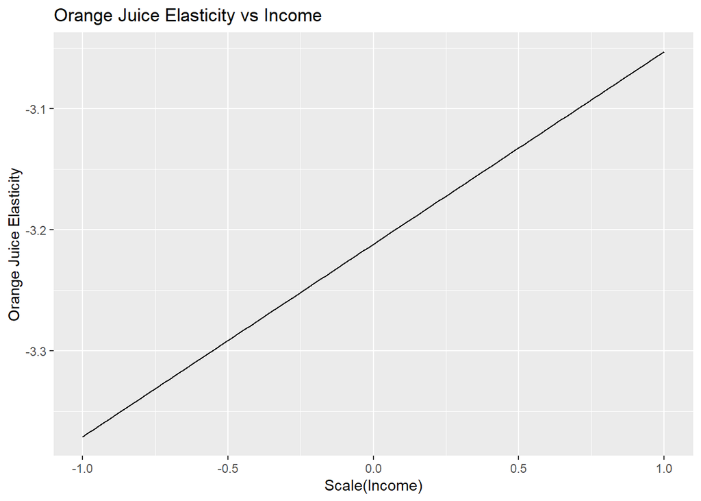

```r
cate_effect <- tibble("X_test" = X_test, "te_pred" = py$te_pred)

cate_effect %>%
  ggplot(aes(X_test, te_pred)) +
  geom_line() +
  labs(
    x = "Scale(Income)",
    y = "Orange Juice Elasticity",
    title = "Orange Juice Elasticity vs Income"
  )
```

## Bootstrap Confidence Intervals

```python
from econml.bootstrap import BootstrapEstimator
```

```python
boot_est = BootstrapEstimator(DMLCateEstimator(model_y=RandomForestRegressor(),model_t=RandomForestRegressor()),n_bootstrap_samples=20)

boot_est.fit(r.Y, r.D, r.X, r.W)
```

```
## <econml.bootstrap.BootstrapEstimator object at 0x00000000298F46A0>
##
## [Parallel(n_jobs=1)]: Using backend SequentialBackend with 1 concurrent workers.
## [Parallel(n_jobs=1)]: Done   1 out of   1 | elapsed:    2.0s remaining:    0.0s
## [Parallel(n_jobs=1)]: Done   2 out of   2 | elapsed:    3.7s remaining:    0.0s
## [Parallel(n_jobs=1)]: Done  20 out of  20 | elapsed:   38.0s finished
```

```python
te_pred_interval = boot_est.const_marginal_effect_interval(r.X_test, lower=1, upper=99)
```

```
## [Parallel(n_jobs=1)]: Using backend SequentialBackend with 1 concurrent workers.
## [Parallel(n_jobs=1)]: Done   1 out of   1 | elapsed:    0.0s remaining:    0.0s
## [Parallel(n_jobs=1)]: Done   2 out of   2 | elapsed:    0.0s remaining:    0.0s
## [Parallel(n_jobs=1)]: Done  20 out of  20 | elapsed:    0.0s finished
```

```r
cate_effect_interval <- cate_effect %>%
  mutate(
    te_pred_down = py$te_pred_interval[[1]],
    te_pred_up   = py$te_pred_interval[[2]]
  )

head(cate_effect_interval)
```

```
## # A tibble: 6 x 4
##   X_test[,1] te_pred te_pred_down te_pred_up
##        <dbl>   <dbl>        <dbl>      <dbl>
## 1       1      -3.05        -3.11      -2.99
## 2       0.98   -3.06        -3.12      -2.99
## 3       0.96   -3.06        -3.12      -2.99
## 4       0.94   -3.06        -3.12      -3.00
## 5       0.92   -3.07        -3.12      -3.00
## 6       0.9    -3.07        -3.13      -3.01
```

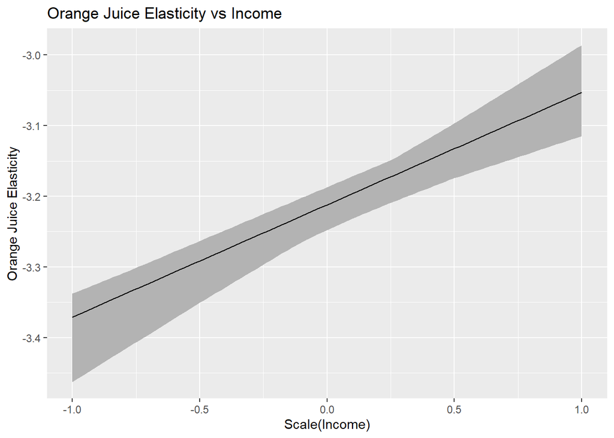

```r
cate_effect_interval %>%
  ggplot(aes(X_test, te_pred)) +
  geom_ribbon(aes(ymin = te_pred_down, ymax = te_pred_up),
              fill = "grey70") +
  geom_line() +
  labs(
    x = "Scale(Income)",
    y = "Orange Juice Elasticity",
    title = "Orange Juice Elasticity vs Income",
    fill  = "1-99% CI"
  )
```